# Good Plot v Bad Plot Lab

Danielle Barnas

3/10/2021

# Instructions:

Due March 22

Your homework is to create two versions of similar plots, using any dataset you choose. You must create the plots using ggplot2, post-processing with Adobe Illustrator or similar is not allowed. This homework is a contest, and the winner will win a prize to be disclosed.

Please submit your homework by posting a markdown document containing the plots, the code you used to create them, and your discussion of the plot within the markdown doc to github. Data also needs to be submitted.

The first plot should be as bad as possible. Your reading from Claus Wilke’s and Healy’s textbook describe the many ways that a plot cab become misleading, difficult to interpret, or or just plain ugly, and you should use all of the tools that you can. Please try to make me, a person who cares a great deal about high-quality data visualization, cry.

You should explain in text all of the ways in which the bad plot is bad. Bullet points are fine, but clearly articulate each principle of data visualization that you have broken.

The second plot should be based on the same or similar data to the first plot, but it should be good. Write briefly about why this is a successful plot.

Rules:  
- All plots must be made in ggplot2, with code visible in the Rmarkdown document. - The data must be visible. - The good plot and the bad plot should be based on the same, or similar, data. - Results will be posted on Twitter.

# Load Libraries

```r
library(tidyverse)
library(here)
library(PNWColors)
library(rgl)
library(ggrgl)
library(ggiraph)
library(devout)
library(devoutrgl)
```

**Read in Data**

```r
rm(list = ls())
plastics <- read_csv(here("Week7","Data","plastics.csv"))
head(plastics)
```

```
## # A tibble: 6 x 14
##   country  year parent_company empty  hdpe  ldpe     o   pet    pp    ps   pvc
##   <chr>   <dbl> <chr>          <dbl> <dbl> <dbl> <dbl> <dbl> <dbl> <dbl> <dbl>
## 1 Argent…  2019 Grand Total        0   215    55   607  1376   281   116    18
## 2 Argent…  2019 Unbranded          0   155    50   532   848   122   114    17
## 3 Argent…  2019 The Coca-Cola…     0     0     0     0   222    35     0     0
## 4 Argent…  2019 Secco              0     0     0     0    39     4     0     0
## 5 Argent…  2019 Doble Cola         0     0     0     0    38     0     0     0
## 6 Argent…  2019 Pritty             0     0     0     0    22     7     0     0
## # … with 3 more variables: grand_total <dbl>, num_events <dbl>,
## #   volunteers <dbl>
```

# Bad Plot

**Analyze and Graph Data**

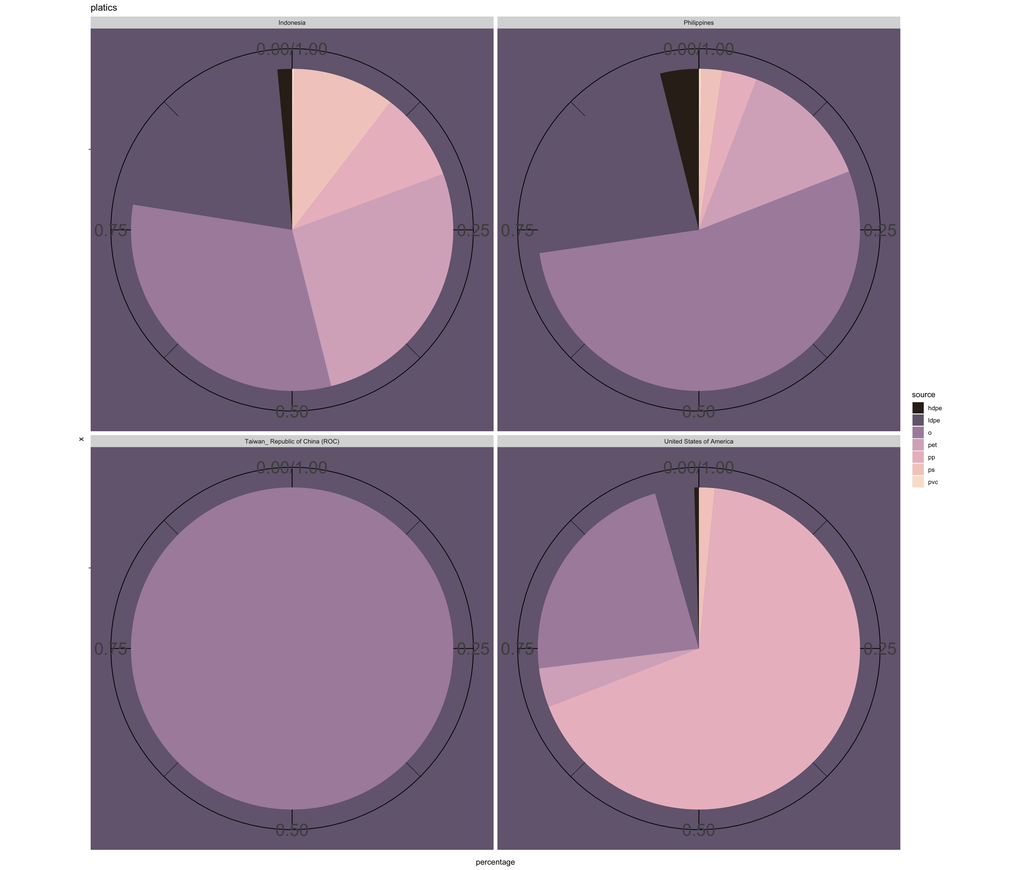

```r
# Set color palette
pal<-pnw_palette("Shuksan")

# pivot longer by plastic types
plastics.long<-plastics %>%
  filter(year == 2019) %>%
  filter(parent_company == "Grand Total") %>% # remove subcategories; only retain totals
  filter(grand_total > 0) %>% # remove empty categories
  arrange(desc(grand_total)) %>%  # Filter by grand_total to identify top 4 countries with greatest recorded plastic pollution
  pivot_longer(cols = c(hdpe:pvc), names_to = "source", values_to = "counts") %>%  # plastic counts in long format
  mutate(percentage = counts/grand_total) %>%
  select(country, source, percentage)

# isolate the top 4 countries and the US
plastics.long<-plastics.long %>%
  filter(country == "Taiwan_ Republic of China (ROC)" |
          country == "Philippines" |
          country == "Indonesia" |
          country == "United States of America")

# pie charts
ggplot(plastics.long,
                aes(x="", y=percentage, fill=source)) +
  geom_bar(stat="identity", width=1) +
  coord_polar("y", start=0) +
  labs(title = "platics") +
  scale_fill_manual(values = pal) +
  facet_wrap(~country, ncol = 2) +
  theme(axis.text.x = element_text(size = 24),
        axis.text.y = element_text(size = 24),
        panel.grid.major = element_line(colour = "black"),
        panel.grid.minor = element_line(colour = "black"),
        panel.background = element_rect(colour = pal[2], fill = pal[2])) +
  ggsave(here("Week7","Output","Bad_Plot.pdf"))
```

**Problems**  
- Legend too small  
- X-Axis text too small  
- Labels on graphs themselves not present  
- Background color is the same as one of the pie chart colors  
- Unnecessary axis lines and labels  
- Title is small and vague  
- Colors used are very similar to each other, not easy to discern at a glance  
- One of the top countries only has one type of plastic represented

# Good plot

**Analyze and Graph Data**

```r
plastics.long.2<-plastics %>%
  filter(parent_company == "Grand Total") %>% # only keep country grand totals
  filter(grand_total > 0) %>%
  rename(HDPE = "hdpe", LDPE = "ldpe", Other = "o",
         PET = "pet", PP = "pp", PS = "ps", PVC = "pvc") %>%
  pivot_longer(cols = c(HDPE:PVC), # all plastic types in one column, except for grand total
               names_to = "source",
               values_to = "num_collected") %>%
  filter(year == 2019) %>%
  filter(country != "EMPTY")

# Set color palette
pal2<-pnw_palette("Bay",7)

good.plot<-ggplot(plastics.long.2,
       aes(x = reorder(country, grand_total),
           y = num_collected,
           colour = source,
           fill = source,
           tooltip = source, data_id = source)) +
  geom_col_interactive(stat = "identity", colour = "black") +
  scale_fill_manual_interactive(values = pal2) +
  scale_color_manual_interactive(values = pal2) +
  theme_bw() +
  labs(x = "Country",
       y = "Recorded Counted Plastic",
       title = "Total Recorded Plastic Pollution",
       subtitle = "Counted in 2019",
       fill = "Plastic Type",
       colour = "Plastic Type") +
   theme(legend.position=c(.85,.3), # place legend inside the plot
         axis.text = element_text_interactive(size = 6),
         panel.grid.major = element_blank(),
         panel.grid.minor = element_blank()) +
   coord_flip()+
   ggsave(here("Week7","Output","Good_Plot_stagnant.pdf"))

x <- girafe(ggobj = good.plot)
girafe_options(x, opts_hover(reactive = TRUE),
               opts_zoom(min = .5, max = 4))
```

[interactive chart not shown]